# Presentation Graphs

# Von Bertalanffy Growth Formula for BLC

For this graph I was interested in trying to predict the mean length in milimeters at any age for Black Crappie. I used data from the LTER in a variety of surveys. I started this graph by loading, data wrangling, and filtering my data to Waupaca county. From there I fitted a von Bertalanffy growth model which is used to predict the mean length of a fish at any age. Then I plotted the von Bertalanffy growth model using predicted values. I chose to use a gray scale because the graph is meant for a scientific audience.

```r
library(FSA)
library(car)
library(tidyverse)
setwd("~/Downloads/MTH 250")

blc <- read.csv("fish_raw_data_BLC_Fyke.csv",na.strings = c("","-"),
                stringsAsFactors = FALSE) %>%
  rename(species=`Species`,tl=`Length.or.Lower.Length.MM`,
         age=`Age.observed.annuli`) %>%
  mutate(tl=as.numeric(tl)) %>%
  filterD(!is.na(age),!is.na(tl),tl>0) %>%
  select(County,Survey.Year,species,tl,age)
```

```
#R> Warning: NAs introduced by coercion
```

```r
str(blc)
```

```
#R> 'data.frame':   5393 obs. of  5 variables:
#R>  $ County     : chr  "PRICE" "PRICE" "PRICE" "PRICE" ...
#R>  $ Survey.Year: int  1992 1992 1992 1992 1992 1992 1992 1992 1992 1992 ...
#R>  $ species    : chr  "BLACK CRAPPIE" "BLACK CRAPPIE" "BLACK CRAPPIE" "BLACK CRAPPIE" ...
#R>  $ tl         : num  83.8 198.1 203.2 210.8 215.9 ...
#R>  $ age        : int  1 5 4 5 5 4 4 4 5 4 ...
```

```r
xtabs(~County,data=blc)
```

```
#R> County
#R>      CLARK   COLUMBIA       DANE      DODGE    DOUGLAS   FLORENCE
#R>          5        224        197         64        119         58
#R> GREEN LAKE       IOWA  JEFFERSON  MANITOWOC  MARINETTE  MARQUETTE
#R>         89         71         79        691        790         98
#R>     OCONTO    PORTAGE      PRICE       RUSK       SAUK     SAWYER
#R>        900          9         57          6        169         48
#R>    SHAWANO    WAUPACA   WAUSHARA
#R>        979        478        262
```

```r
blc <- filterD(blc,County=="WAUPACA")

vb <- vbFuns(param="Typical")
f.starts <- vbStarts(tl~age,data=blc)
f.fit <- nls(tl~vb(age,Linf,K,t0),data=blc,start=f.starts)
coef(f.fit)
```

```
#R>        Linf           K          t0
#R> 314.0180431   0.3166279   0.1712702
```

```r
f.boot1 <- car::Boot(f.fit)
```

```
#R> Loading required namespace: boot
```

```
#R>
#R>  Number of bootstraps was 998 out of 999 attempted
```

```r
confint(f.boot1)
```

```
#R> Bootstrap bca confidence intervals
#R>
#R>            2.5 %      97.5 %
#R> Linf 293.6330495 346.5004542
#R> K      0.2431984   0.3914448
#R> t0    -0.1069832   0.4076209
```

```r
predict2 <- function(x) predict(x,data.frame(age=seq(-1,15,by=0.2)))
predict2(f.fit)  # just a check
```

[output not shown]

```r
f.boot2 <- car::Boot(f.fit,f=predict2)
```

```
#R>
#R>  Number of bootstraps was 998 out of 999 attempted
```

```r
preds1 <- data.frame(seq(-1,15,by=0.2),
                     predict2(f.fit),
                     confint(f.boot2))
names(preds1) <- c("age","fit","LCI","UCI")
headtail(preds1)
```

```
#R>      age        fit       LCI       UCI
#R> V1  -1.0 -140.98647 -226.6449 -87.66924
#R> V2  -0.8 -113.06639 -185.7089 -66.38734
#R> V3  -0.6  -86.85956 -149.4648 -46.22109
#R> V79 14.6  310.76070  290.6448 334.18438
#R> V80 14.8  310.96058  290.7267 334.57603
#R> V81 15.0  311.14819  290.8025 334.95349
```

```
#R> Warning: Removed 26 row(s) containing missing values (geom_path).
```

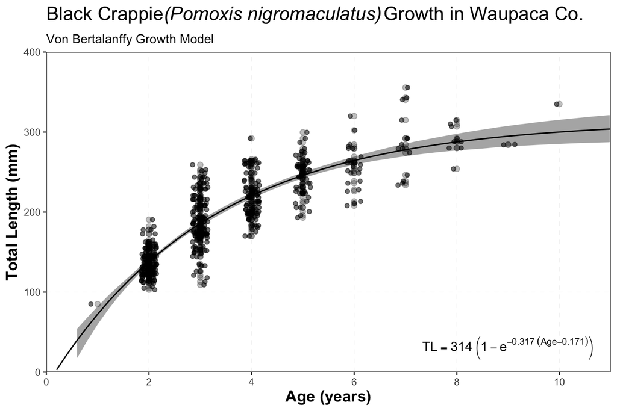

```r
makeVBEqnLabel <- function(fit) {
  cfs <- coef(fit)
  Linf <- formatC(cfs[["Linf"]],format="f",digits=1)
  K <- formatC(cfs[["K"]],format="f",digits=3)
  t0 <- cfs[["t0"]]
  t0 <- paste0(ifelse(t0<0,"+","-"),formatC(abs(t0),format="f",digits=3))
  paste0("TL==",Linf,"~bgroup('(',1-e^{-",K,"~(Age",t0,")},')')")
}

my_title <- expression(paste("Black Crappie", italic("(Pomoxis nigromaculatus)"),
       "Growth in Waupaca Co."))

ggplot() +
  geom_ribbon(data=preds1,aes(x=age,ymin=LCI,ymax=UCI),fill="gray70")+
  geom_point(data=blc,aes(y=tl,x=age),size=2,alpha=0.25) +
  geom_line(data=preds1,aes(y=fit,x=age),size=0.55) +
  geom_jitter(data=blc,aes(y=tl,x=age),
              width=0.15,height=0,alpha=.55)+
  scale_y_continuous(name="Total Length (mm)",expand=c(0,0),limit=c(0,400)) +
  scale_x_continuous(name="Age (years)",expand=c(0,0),
                     limits=c(0,11),breaks=seq(0,12,2))+
  labs(title=my_title,
       subtitle="Von Bertalanffy Growth Model")+
  annotate(geom="text",label=makeVBEqnLabel(f.fit),parse=TRUE,
           size=4,x=Inf,y=-Inf,hjust=1.1,vjust=-0.5)+
  theme_MJL
```